# Talk figures: body composition, glycemia and AD

Positive control, the survival-bias paradox, SlopeHunter correction, glycemic traits

Author

Dave Bridges and Katie Kittell

Published

October 14, 2026

Slide-ready figures, in talk order. Everything is read from `results/pipeline/` (nothing is recomputed), so the numbers always match `results.csv` and `SUMMARY.md`. Figures are written to `figures/talk-*.png` / `.pdf`.

**What is shown.** Three methods on a common scale (log-OR per unit of the exposure GWAS, plotted as odds ratios), one per job: **IVW** (the standard), **MRBEE** (corrects sample overlap and weak-instrument bias) and **weighted median** (robust to up to half the instrument weight being pleiotropic). MR-APSS, CAUSE and MRAID are on an SD-per-SD scale and cannot share that axis; they appear in the concordance grid at the end, which compares all methods on sign and whether the interval excludes zero.

```r
library(dplyr)
library(tidyr)
library(readr)
library(ggplot2)
library(knitr)

res_dir <- "results/pipeline"
res  <- read_csv(file.path(res_dir, "results.csv"), show_col_types = FALSE)
inst <- read_csv(file.path(res_dir, "instruments_classical.csv"), show_col_types = FALSE)

# ---- talk settings: edit here ------------------------------------------------------------
talk_methods <- c("IVW-MRE"         = "IVW (standard)",
                  "MRBEE"           = "MRBEE (sample overlap)",
                  "Weighted median" = "Weighted median (pleiotropy)")
method_cols  <- setNames(c("#00274c", "#ffcb05", "#9a3324"), talk_methods)
arm_labels   <- c(raw = "Uncorrected", slopehunter = "SlopeHunter-corrected")
arm_cols     <- setNames(c("grey60", "#00274c"), arm_labels)
short <- c(bmi_ukb = "BMI", fatmass_ukb = "Fat mass", leanmass_pei = "Lean mass",
           ffm_ukb = "Fat-free mass", t2d_xue = "Type 2 diabetes",
           fg_dupuis = "Fasting glucose", glu2h_chen = "2 h glucose")
ad_outcome     <- "ad_bellenguez"
body_exposures <- c("t2d_xue", "bmi_ukb", "leanmass_pei")     # slides 2 and 3
glyc_exposures <- c("t2d_xue", "fg_dupuis", "glu2h_chen")         # slide 4
# -------------------------------------------------------------------------------------------

theme_talk <- theme_minimal(base_size = 16) +
  theme(legend.position = "bottom", panel.grid.minor = element_blank(),
        panel.grid.major.y = element_blank(), strip.text = element_text(face = "bold"))

# Rows for a set of exposures -> one outcome, restricted to the talk methods.
talk_rows <- function(exposures, out, arms = c("raw", "slopehunter")) {
  res |>
    filter(exposure %in% exposures, outcome == out, arm %in% arms, method %in% names(talk_methods)) |>
    mutate(method_label = factor(talk_methods[method], levels = talk_methods),
           arm_label    = factor(arm_labels[arm], levels = arm_labels),
           exposure_label = factor(short[exposure], levels = rev(short[exposures])))
}

# Forest of odds ratios: one panel per method, so agreement across methods reads left to right.
forest_or <- function(dat, xlim, xlab = "Odds ratio for AD (95% CI) per unit higher exposure") {
  ggplot(dat, aes(x = exp(b), xmin = exp(ci_lo), xmax = exp(ci_hi),
                  y = exposure_label, colour = arm_label)) +
    geom_vline(xintercept = 1, linetype = "dashed", colour = "grey40") +
    geom_pointrange(position = position_dodge(width = 0.5), linewidth = 0.9, size = 0.7) +
    facet_wrap(~ method_label, nrow = 1) +
    scale_x_log10(limits = xlim) +
    scale_colour_manual(values = arm_cols, drop = FALSE) +
    labs(x = xlab, y = NULL, colour = NULL) +
    theme_talk
}

fmt_table <- function(dat) {
  dat |>
    arrange(desc(exposure_label), arm_label, method_label) |>
    transmute(Exposure = exposure_label, Arm = arm_label, Method = method,
              `OR (95% CI)` = sprintf("%.2f (%.2f, %.2f)", exp(b), exp(ci_lo), exp(ci_hi)),
              p = signif(p, 2), SNPs = n_snp)
}
```

## 1. Positive control: BMI → type 2 diabetes

A relationship everyone accepts, to show what a clean MR result looks like. Each point is one BMI-associated variant; the slope of a line through the origin is the causal estimate.

```r
ctl <- res |>
  filter(exposure == "bmi_ukb", outcome == "t2d_xue", arm == "raw", method %in% names(talk_methods)) |>
  mutate(method_label = factor(talk_methods[method], levels = talk_methods))

# Orient every variant to its BMI-raising allele so the cloud sits in one half-plane.
ctl_snps <- inst |>
  filter(assoc_id == "bmi_ukb__t2d_xue__raw") |>
  mutate(flip = if_else(beta_exposure < 0, -1, 1),
         beta_exposure = beta_exposure * flip, beta_outcome = beta_outcome * flip)
```

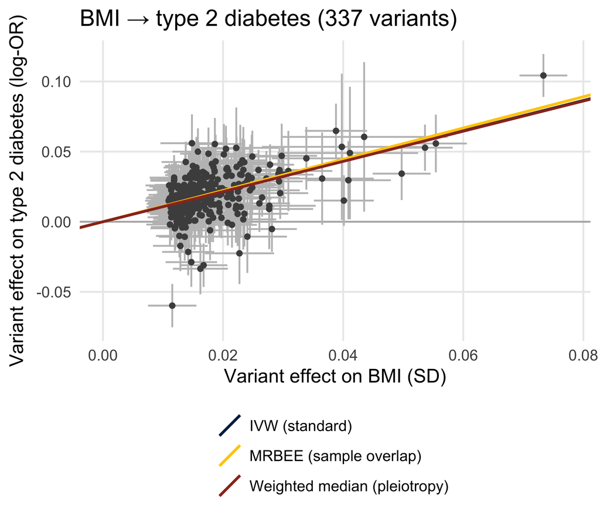

```r
ggplot(ctl_snps, aes(beta_exposure, beta_outcome)) +
  geom_hline(yintercept = 0, colour = "grey70") +
  geom_errorbar(aes(ymin = beta_outcome - 1.96 * se_outcome, ymax = beta_outcome + 1.96 * se_outcome),
                colour = "grey75", width = 0) +
  geom_errorbar(aes(xmin = beta_exposure - 1.96 * se_exposure, xmax = beta_exposure + 1.96 * se_exposure),
                colour = "grey75", width = 0, orientation = "y") +
  geom_point(colour = "grey30", size = 1.6) +
  geom_abline(data = ctl, aes(slope = b, intercept = 0, colour = method_label), linewidth = 1.1) +
  scale_colour_manual(values = method_cols) +
  expand_limits(x = 0) +
  guides(colour = guide_legend(nrow = 3)) +
  labs(x = "Variant effect on BMI (SD)", y = "Variant effect on type 2 diabetes (log-OR)",
       colour = NULL, title = sprintf("BMI → type 2 diabetes (%d variants)", nrow(ctl_snps))) +
  theme_talk + theme(panel.grid.major.y = element_line())
```

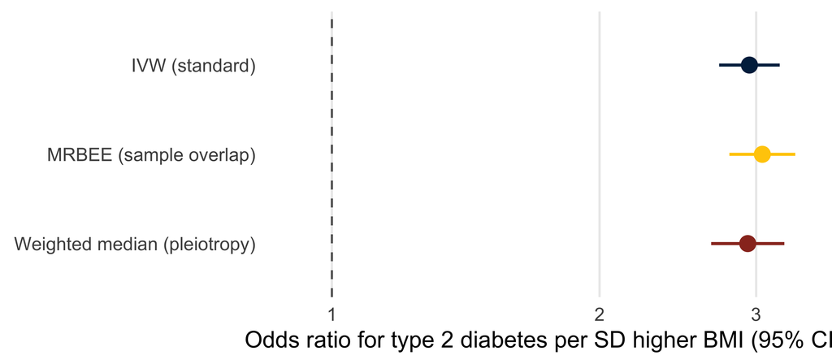

```r
ggplot(ctl, aes(x = exp(b), xmin = exp(ci_lo), xmax = exp(ci_hi),
                y = forcats::fct_rev(method_label), colour = method_label)) +
  geom_vline(xintercept = 1, linetype = "dashed", colour = "grey40") +
  geom_pointrange(linewidth = 1, size = 0.9) +
  scale_x_log10(limits = c(0.9, NA)) +
  scale_colour_manual(values = method_cols, guide = "none") +
  labs(x = "Odds ratio for type 2 diabetes per SD higher BMI (95% CI)", y = NULL) +
  theme_talk
```

```r
ctl |>
  transmute(Method = method, `OR (95% CI)` = sprintf("%.2f (%.2f, %.2f)", exp(b), exp(ci_lo), exp(ci_hi)),
            p = signif(p, 2), SNPs = n_snp) |>
  kable()
```

| Method | OR (95% CI) | p | SNPs |
| --- | --- | --- | --- |
| IVW-MRE | 2.95 (2.73, 3.19) | 0 | 337 |
| MRBEE | 3.05 (2.80, 3.32) | 0 | 337 |
| Weighted median | 2.94 (2.67, 3.23) | 0 | 337 |

## 2. The paradox: uncorrected estimates for AD

Type 2 diabetes shows nothing, and **both** BMI and lean mass look protective. Higher BMI protecting against AD is the result that should make the audience suspicious.

```r
body <- talk_rows(body_exposures, ad_outcome)
# One x-range for slides 2 and 3, so slide 3 is slide 2 with the corrected points added.
body_xlim <- range(exp(c(body$ci_lo, body$ci_hi)))
```

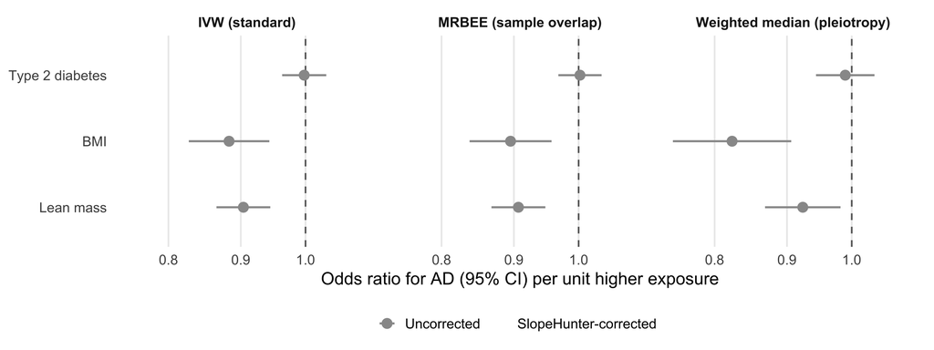

```r
forest_or(filter(body, arm == "raw"), body_xlim)
```

## 3. Survival bias and its correction

AD cases have to live long enough to be diagnosed, so anything that shortens life is depleted among cases and looks protective. SlopeHunter estimates that selection slope from the genome-wide lifespan–AD relationship and removes it.

### Who survives? Both arms of the collider

Survival is a collider only if **both** the exposure and AD liability affect it. AD liability shortens parental lifespan, and so do BMI and type 2 diabetes; lean mass does not. That predicts which estimates the correction should move. IVW only: the AD → lifespan arm comes from the Step 1 screen (`ad_longevity_arm.csv`), which has standard errors for IVW alone. Units differ by row (log-odds of AD or T2D, SD of BMI or lean mass), so read direction and whether the interval excludes zero, not relative size.

```r
ad_life <- read_csv("ad_longevity_arm.csv", show_col_types = FALSE) |>
  filter(grepl("Bellenguez", exposure), grepl("Martingale", survival)) |>
  transmute(label = "AD liability", arm = "Outcome arm", b, ci_lo = b - 1.96 * se, ci_hi = b + 1.96 * se,
            p, n_snp)

survival <- res |>
  filter(exposure %in% body_exposures, outcome == "lifespan", method == "IVW-MRE") |>
  transmute(label = short[exposure], arm = "Exposure arm", b, ci_lo, ci_hi, p, n_snp) |>
  bind_rows(ad_life) |>
  mutate(label = factor(label, levels = rev(c("AD liability", short[c("bmi_ukb", "t2d_xue", "leanmass_pei")]))),
         arm = factor(arm, levels = c("Outcome arm", "Exposure arm")))
```

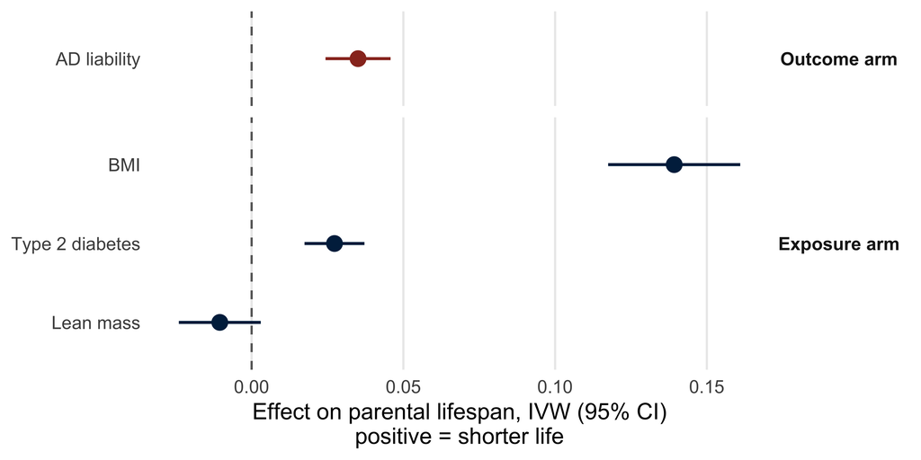

```r
ggplot(survival, aes(x = b, xmin = ci_lo, xmax = ci_hi, y = label, colour = arm)) +
  geom_vline(xintercept = 0, linetype = "dashed", colour = "grey40") +
  geom_pointrange(linewidth = 1, size = 0.9) +
  facet_grid(arm ~ ., scales = "free_y", space = "free_y") +
  scale_colour_manual(values = c("Outcome arm" = "#9a3324", "Exposure arm" = "#00274c"), guide = "none") +
  labs(x = "Effect on parental lifespan, IVW (95% CI)\npositive = shorter life", y = NULL) +
  theme_talk + theme(strip.text.y = element_text(angle = 0))
```

```r
survival |>
  arrange(arm, desc(label)) |>
  transmute(Arm = arm, Trait = label, `b (95% CI)` = sprintf("%.3f (%.3f, %.3f)", b, ci_lo, ci_hi),
            p = signif(p, 2), SNPs = n_snp) |>
  kable()
```

| Arm | Trait | b (95% CI) | p | SNPs |
| --- | --- | --- | --- | --- |
| Outcome arm | AD liability | 0.035 (0.024, 0.046) | 0.0e+00 | 54 |
| Exposure arm | BMI | 0.139 (0.117, 0.161) | 0.0e+00 | 419 |
| Exposure arm | Type 2 diabetes | 0.027 (0.017, 0.037) | 1.0e-07 | 109 |
| Exposure arm | Lean mass | -0.010 (-0.024, 0.003) | 1.3e-01 | 548 |

### Corrected estimates

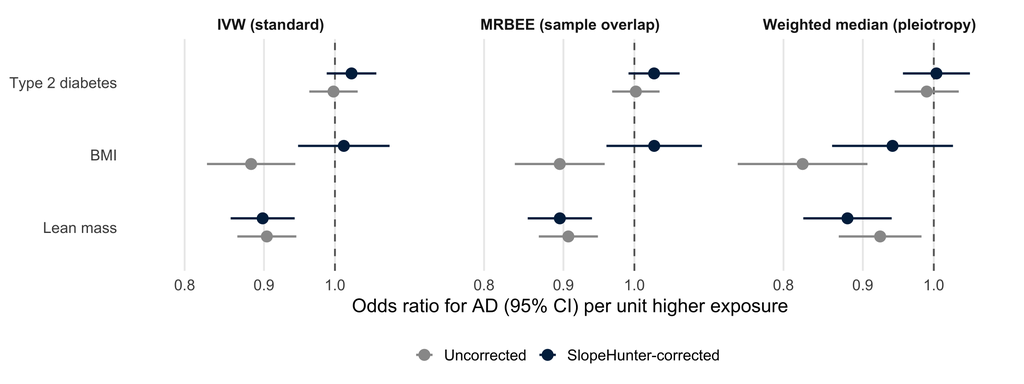

```r
forest_or(body, body_xlim)
```

```r
kable(fmt_table(body))
```

| Exposure | Arm | Method | OR (95% CI) | p | SNPs |
| --- | --- | --- | --- | --- | --- |
| Type 2 diabetes | Uncorrected | IVW-MRE | 1.00 (0.96, 1.03) | 9.1e-01 | 115 |
| Type 2 diabetes | Uncorrected | MRBEE | 1.00 (0.97, 1.04) | 9.0e-01 | 115 |
| Type 2 diabetes | Uncorrected | Weighted median | 0.99 (0.94, 1.04) | 6.6e-01 | 115 |
| Type 2 diabetes | SlopeHunter-corrected | IVW-MRE | 1.02 (0.99, 1.06) | 1.9e-01 | 109 |
| Type 2 diabetes | SlopeHunter-corrected | MRBEE | 1.03 (0.99, 1.07) | 1.3e-01 | 109 |
| Type 2 diabetes | SlopeHunter-corrected | Weighted median | 1.00 (0.96, 1.06) | 8.8e-01 | 109 |
| BMI | Uncorrected | IVW-MRE | 0.88 (0.83, 0.94) | 2.0e-04 | 414 |
| BMI | Uncorrected | MRBEE | 0.90 (0.84, 0.96) | 1.1e-03 | 414 |
| BMI | Uncorrected | Weighted median | 0.82 (0.75, 0.91) | 7.3e-05 | 414 |
| BMI | SlopeHunter-corrected | IVW-MRE | 1.01 (0.95, 1.08) | 7.0e-01 | 403 |
| BMI | SlopeHunter-corrected | MRBEE | 1.03 (0.96, 1.11) | 4.2e-01 | 403 |
| BMI | SlopeHunter-corrected | Weighted median | 0.94 (0.86, 1.03) | 1.8e-01 | 403 |
| Lean mass | Uncorrected | IVW-MRE | 0.90 (0.87, 0.94) | 6.0e-06 | 598 |
| Lean mass | Uncorrected | MRBEE | 0.91 (0.87, 0.95) | 1.2e-05 | 598 |
| Lean mass | Uncorrected | Weighted median | 0.92 (0.87, 0.98) | 1.1e-02 | 598 |
| Lean mass | SlopeHunter-corrected | IVW-MRE | 0.90 (0.86, 0.94) | 9.6e-06 | 531 |
| Lean mass | SlopeHunter-corrected | MRBEE | 0.90 (0.85, 0.94) | 5.4e-06 | 531 |
| Lean mass | SlopeHunter-corrected | Weighted median | 0.88 (0.82, 0.94) | 1.3e-04 | 531 |

## 4. Glycemic traits → AD, SlopeHunter-corrected

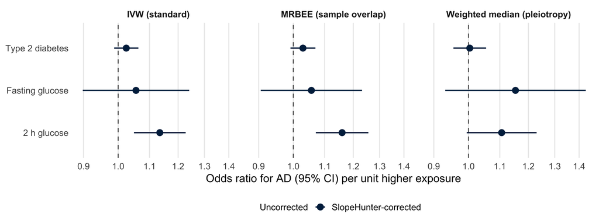

```r
glyc <- talk_rows(glyc_exposures, ad_outcome)
forest_or(filter(glyc, arm == "slopehunter"), range(exp(c(glyc$ci_lo, glyc$ci_hi))))
```

```r
kable(fmt_table(glyc))
```

| Exposure | Arm | Method | OR (95% CI) | p | SNPs |
| --- | --- | --- | --- | --- | --- |
| Type 2 diabetes | Uncorrected | IVW-MRE | 1.00 (0.96, 1.03) | 0.91000 | 115 |
| Type 2 diabetes | Uncorrected | MRBEE | 1.00 (0.97, 1.04) | 0.90000 | 115 |
| Type 2 diabetes | Uncorrected | Weighted median | 0.99 (0.94, 1.04) | 0.66000 | 115 |
| Type 2 diabetes | SlopeHunter-corrected | IVW-MRE | 1.02 (0.99, 1.06) | 0.19000 | 109 |
| Type 2 diabetes | SlopeHunter-corrected | MRBEE | 1.03 (0.99, 1.07) | 0.13000 | 109 |
| Type 2 diabetes | SlopeHunter-corrected | Weighted median | 1.00 (0.96, 1.06) | 0.88000 | 109 |
| Fasting glucose | Uncorrected | IVW-MRE | 1.06 (0.91, 1.25) | 0.43000 | 11 |
| Fasting glucose | Uncorrected | MRBEE | 1.07 (0.93, 1.22) | 0.36000 | 11 |
| Fasting glucose | Uncorrected | Weighted median | 1.10 (0.89, 1.36) | 0.36000 | 11 |
| Fasting glucose | SlopeHunter-corrected | IVW-MRE | 1.06 (0.90, 1.24) | 0.51000 | 11 |
| Fasting glucose | SlopeHunter-corrected | MRBEE | 1.06 (0.91, 1.23) | 0.48000 | 11 |
| Fasting glucose | SlopeHunter-corrected | Weighted median | 1.15 (0.93, 1.43) | 0.19000 | 11 |
| 2 h glucose | Uncorrected | IVW-MRE | 1.10 (1.01, 1.21) | 0.03500 | 12 |
| 2 h glucose | Uncorrected | MRBEE | 1.11 (1.00, 1.22) | 0.04100 | 12 |
| 2 h glucose | Uncorrected | Weighted median | 1.14 (1.03, 1.27) | 0.01400 | 12 |
| 2 h glucose | SlopeHunter-corrected | IVW-MRE | 1.14 (1.05, 1.23) | 0.00160 | 12 |
| 2 h glucose | SlopeHunter-corrected | MRBEE | 1.16 (1.07, 1.26) | 0.00027 | 12 |
| 2 h glucose | SlopeHunter-corrected | Weighted median | 1.11 (0.99, 1.23) | 0.06300 | 12 |

## Instrument strength

For the genome-wide-significant (p < 5×10⁻⁸) instrument sets behind the three plotted methods, as used for the Bellenguez AD outcome. **F** is strength per instrument and governs weak-instrument bias (conventional floor of 10); **R²** is the share of exposure variance the whole set explains and governs power. Every exposure clears F > 10 comfortably. They differ in R² and in instrument count, which is why the glucose intervals are wide. R² for type 2 diabetes is converted from the observed case/control scale to the **liability scale** (Lee et al. 2011), so it is comparable with the continuous traits and with heritability; the conversion depends on the assumed population prevalence set below. F is scale-free and is unchanged.

```r
strength_exposures <- unique(c("bmi_ukb", body_exposures, glyc_exposures))
# Binary exposures: observed-scale R² -> liability scale. VERIFY the counts against the GWAS paper
# and choose the prevalence deliberately; the factor is about 2.8 at 8% and 3.1 at 10%.
binary_exposures <- tibble::tibble(exposure = "t2d_xue", n_case = 62892, n_control = 596424,
                                   prevalence = 0.10)
liability_factor <- function(K, P) {
  z <- dnorm(qnorm(1 - K))                 # normal density at the liability threshold
  K^2 * (1 - K)^2 / (z^2 * P * (1 - P))    # K = population prevalence, P = sample case fraction
}

strength <- res |>
  filter(exposure %in% strength_exposures, outcome == ad_outcome, arm == "raw", method == "IVW-MRE") |>
  left_join(binary_exposures, by = "exposure") |>
  mutate(R2_observed = R2,
         R2 = R2 * coalesce(liability_factor(prevalence, n_case / (n_case + n_control)), 1)) |>
  transmute(exposure_label = factor(short[exposure], levels = rev(short[strength_exposures])),
            n_snp, `Variance explained, R² (%)` = 100 * R2, `Mean F per instrument` = mean_F,
            total_F, N_exposure, R2_observed, binary = !is.na(prevalence))
```

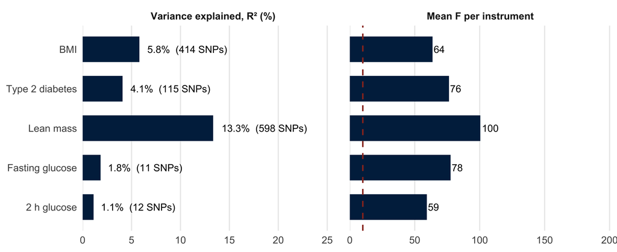

```r
strength |>
  pivot_longer(c(`Variance explained, R² (%)`, `Mean F per instrument`), names_to = "metric") |>
  mutate(metric = factor(metric, levels = c("Variance explained, R² (%)", "Mean F per instrument")),
         label = if_else(metric == "Mean F per instrument", sprintf("%.0f", value),
                         sprintf("%.1f%%  (%d SNPs)", value, n_snp))) |>
  ggplot(aes(value, exposure_label)) +
  geom_col(fill = "#00274c", width = 0.65) +
  geom_vline(data = data.frame(metric = factor("Mean F per instrument"), x = 10),
             aes(xintercept = x), linetype = "dashed", colour = "#9a3324", linewidth = 0.9) +
  geom_text(aes(label = label), hjust = -0.1, size = 4.5) +
  facet_wrap(~ metric, scales = "free_x") +
  scale_x_continuous(expand = expansion(mult = c(0, 1))) +
  labs(x = NULL, y = NULL) +
  theme_talk
```

```r
strength |>
  arrange(desc(exposure_label)) |>
  transmute(Exposure = exposure_label, SNPs = n_snp, `GWAS N` = N_exposure,
            `R² (%)` = round(`Variance explained, R² (%)`, 2),
            `R² observed scale (%)` = if_else(binary, as.character(round(100 * R2_observed, 2)), "—"),
            `Mean F` = round(`Mean F per instrument`, 1), `Overall F` = round(total_F, 1)) |>
  kable()
```

| Exposure | SNPs | GWAS N | R² (%) | R² observed scale (%) | Mean F | Overall F |
| --- | --- | --- | --- | --- | --- | --- |
| BMI | 414 | 454884 | 5.80 | — | 63.7 | 67.6 |
| Type 2 diabetes | 115 | 655666 | 4.08 | 1.34 | 76.4 | 77.4 |
| Lean mass | 598 | 450243 | 13.34 | — | 100.5 | 115.7 |
| Fasting glucose | 11 | 46368 | 1.84 | — | 77.6 | 78.8 |
| 2 h glucose | 12 | 63396 | 1.12 | — | 59.3 | 59.9 |

## 5. Concordance across every method

The three methods above share a scale. This grid adds the rest (MR-APSS, CAUSE and MRAID are SD-per-SD), comparing them the only way that is valid across scales: direction, and whether the 95% interval excludes zero. Blank cells were not run for that pair.

```r
grid_methods <- c("IVW-MRE", "MR-PRESSO", "MR-RAPS", "MRBEE", "Weighted median", "Weighted mode",
                  "MR-Egger", "MR-APSS", "MR-APSS (p<5e-8)", "CAUSE", "MRAID")
grid_exposures <- unique(c(body_exposures, glyc_exposures))
calls <- c("Lower risk, interval excludes 0", "Lower risk, n.s.",
           "Higher risk, n.s.", "Higher risk, interval excludes 0")

conc <- res |>
  filter(exposure %in% grid_exposures, outcome == ad_outcome, method %in% grid_methods) |>
  mutate(excl = ci_lo * ci_hi > 0,
         call = factor(case_when(b < 0 & excl ~ calls[1], b < 0 ~ calls[2],
                                 b >= 0 & !excl ~ calls[3], TRUE ~ calls[4]), levels = calls),
         method = factor(method, levels = grid_methods),
         family = if_else(grepl("^SD", scale), "SD per SD", "log-OR per unit"),
         arm_label = factor(arm_labels[arm], levels = rev(arm_labels)),
         exposure_label = factor(short[exposure], levels = short[grid_exposures]))

ggplot(conc, aes(method, arm_label, fill = call)) +
  geom_tile(colour = "white", linewidth = 1.2) +
  geom_text(aes(label = sprintf("%+.2f", b), colour = excl), size = 3.4, show.legend = FALSE) +
  facet_grid(exposure_label ~ family, scales = "free_x", space = "free_x", switch = "y") +
  scale_fill_manual(values = setNames(c("#00274c", "#9fb4cc", "#f2c9a5", "#9a3324"), calls), drop = FALSE) +
  scale_colour_manual(values = c(`TRUE` = "white", `FALSE` = "grey15")) +
  guides(fill = guide_legend(nrow = 2)) +
  labs(x = NULL, y = NULL, fill = NULL) +
  theme_talk +
  theme(axis.text.x = element_text(angle = 35, hjust = 1), strip.placement = "outside",
        strip.text.y.left = element_text(angle = 0, hjust = 1), panel.grid = element_blank())
```

[figure not shown]

```r
conc |>
  group_by(Exposure = exposure_label, Arm = arm_label) |>
  summarise(Methods = n(),
            `Lower risk` = sum(b < 0), `Higher risk` = sum(b >= 0),
            `Interval excludes 0` = sum(excl), .groups = "drop") |>
  arrange(Exposure, desc(Arm)) |>
  kable()
```

| Exposure | Arm | Methods | Lower risk | Higher risk | Interval excludes 0 |
| --- | --- | --- | --- | --- | --- |
| Type 2 diabetes | Uncorrected | 10 | 4 | 6 | 0 |
| Type 2 diabetes | SlopeHunter-corrected | 10 | 0 | 10 | 0 |
| BMI | Uncorrected | 10 | 10 | 0 | 9 |
| BMI | SlopeHunter-corrected | 10 | 3 | 7 | 0 |
| Lean mass | Uncorrected | 10 | 10 | 0 | 9 |
| Lean mass | SlopeHunter-corrected | 10 | 10 | 0 | 9 |
| Fasting glucose | Uncorrected | 11 | 4 | 7 | 0 |
| Fasting glucose | SlopeHunter-corrected | 11 | 4 | 7 | 0 |
| 2 h glucose | Uncorrected | 11 | 0 | 11 | 7 |
| 2 h glucose | SlopeHunter-corrected | 11 | 0 | 11 | 6 |

## 6. Is 2 h glucose different from fasting glucose?

Sections 6–8 read `results/pipeline/contrast/` (the fasting vs 2 h glucose extension; see `pipeline/README.md`). Instruments are T2D-associated variants; each variant’s effects on fasting and 2 h glucose (Chen 2021, both BMI-adjusted) enter one multivariable model, so each estimate is adjusted for the other. The outcome is SlopeHunter-corrected Bellenguez AD.

**Which instrument set.** The figure shows the **Xue 2018** T2D instruments (109 variants), a pre-declared sensitivity set. The pre-specified primary set (Suzuki 2024, 273 variants) points the same way but is not significant; both are in the table. The larger set adds many variants with almost no effect on 2 h glucose.

### How the model works

**Instruments.** Variants associated with type 2 diabetes at $p < 5\times10^{-8}$, clumped to independence ($r^2 < 0.001$ within 10 Mb), with variants within 500 kb of *APOE* removed. For each variant $j = 1,\dots,J$ we take three numbers from three different studies, all aligned to the T2D risk-raising allele:

- $\hat\beta_{Fj}$: effect on fasting glucose (mmol/L, Chen 2021)
- $\hat\beta_{2j}$: effect on 2 h glucose (mmol/L, Chen 2021)
- $\hat\beta_{Yj}$: effect on AD (log-odds, Bellenguez 2022 after SlopeHunter correction)

Selecting on T2D rather than on either glucose trait means the variants were not chosen for being strong on fasting or on 2 h glucose specifically, and the T2D GWAS is a different study from the glucose GWAS, so selection does not inflate the glucose effects.

**Model (multivariable MR).** Each variant’s effect on AD is modelled as the sum of what it does through fasting glucose and what it does through 2 h glucose:

$$\hat\beta_{Yj} \;=\; \theta_F\,\hat\beta_{Fj} \;+\; \theta_2\,\hat\beta_{2j} \;+\; \varepsilon_j,
\qquad \varepsilon_j \sim N\!\left(0,\ \phi\,\sigma_{Yj}^2\right)$$

with no intercept and $\sigma_{Yj}$ the standard error of $\hat\beta_{Yj}$. $\theta_2$ is the effect on AD of 1 mmol/L higher 2 h glucose **at fixed fasting glucose**, and $\theta_F$ the reverse; the plot shows $e^{\theta}$ as odds ratios. This is identified only because the variants differ in their *mix* of fasting and 2 h effects (see the validation figure below): if every variant moved the two in the same proportion, $\theta_F$ and $\theta_2$ could not be told apart.

**Is 2 h different from fasting?** The headline test is the difference, with its standard error from the full covariance of the two estimates (they are strongly negatively correlated, so comparing their two confidence intervals would be wrong):

$$\Delta = \theta_2 - \theta_F, \qquad
\operatorname{SE}(\hat\Delta) = \sqrt{\operatorname{Var}(\hat\theta_2) + \operatorname{Var}(\hat\theta_F) - 2\operatorname{Cov}(\hat\theta_2, \hat\theta_F)}$$

In the plot, $e^{\Delta}$ is the ratio of the two odds ratios.

**Two estimators.**

- *IVW (multiplicative random effects).* Weighted least squares of $\hat\beta_{Yj}$ on $(\hat\beta_{Fj}, \hat\beta_{2j})$ with weights $1/\sigma_{Yj}^2$; standard errors scaled by $\sqrt{\phi}$, the residual standard error, floored at 1. It treats the glucose effects as known exactly, so noise in them (weak instruments) biases the estimates; in the multivariable setting the bias can go in either direction.
- *MRBEE (bias-corrected estimating equations).* Subtracts the expected contribution of that noise. With $\mathbf{x}_j = (\hat\beta_{Fj}, \hat\beta_{2j})^\top$, weights $w_j = 1/\sigma_{Yj}^2$ and $\boldsymbol\Sigma_j$ the covariance of the estimation errors in $\mathbf{x}_j$ (built from their standard errors and the fasting/2 h error correlation, $\rho = 0.11$, which comes from the shared MAGIC cohorts),

$$\hat{\boldsymbol\theta}_{\text{MRBEE}} \;=\; \Big(\textstyle\sum_j w_j\big(\mathbf{x}_j\mathbf{x}_j^\top - \boldsymbol\Sigma_j\big)\Big)^{-1}
\textstyle\sum_j w_j\big(\mathbf{x}_j\,\hat\beta_{Yj} - \boldsymbol\sigma_{xY,j}\big)$$

where $\boldsymbol\sigma_{xY,j}$ is the error covariance between the glucose and AD estimates (near zero here: about 0.003). It also removes variants flagged as pleiotropic outliers.

**Instrument strength (conditional F).** The usual F asks whether the variants predict an exposure; the multivariable question is whether they predict it **beyond what the other exposure explains**. The Sanderson–Windmeijer conditional F for 2 h glucose regresses the 2 h effects on the fasting effects and asks how much variation is left over, relative to its noise:

$$F_{2\mid F} \;=\; \frac{1}{J-1}\sum_j
\frac{\big(\hat\beta_{2j} - \hat\delta\,\hat\beta_{Fj}\big)^2}
{\sigma_{2j}^2 + \hat\delta^2\sigma_{Fj}^2 - 2\hat\delta\,\rho\,\sigma_{2j}\sigma_{Fj}}$$

where $\hat\delta$ is the fitted slope of $\hat\beta_{2j}$ on $\hat\beta_{Fj}$. Values above 10 are the conventional comfort zone. For the Xue set $F_{F\mid 2} = 14.2$ and $F_{2\mid F} = 5.6$; for the Suzuki set 11.1 and 4.1. Fasting glucose is well separated from 2 h glucose, but 2 h glucose is only weakly separated from fasting, which is why MRBEE is the estimator to trust.

```r
con_dir <- file.path(res_dir, "contrast")
con     <- read_csv(file.path(con_dir, "results.csv"), show_col_types = FALSE)
con_cl  <- read_csv(file.path(con_dir, "cluster_results.csv"), show_col_types = FALSE)
con_dt  <- read_csv(file.path(con_dir, "drug_target_results.csv"), show_col_types = FALSE)

# ---- settings for sections 6-8: edit here ---------------------------------------------------
con_set     <- "xue"            # instrument set plotted in section 6 ("primary" = Suzuki 2024)
con_arm     <- "slopehunter"    # outcome arm for all three sections
con_scale   <- "per mmol/L"
con_methods <- c("IVW-MRE" = "IVW (standard)", "MRBEE" = "MRBEE (weak instruments, overlap)")
con_cols    <- setNames(c("#00274c", "#ffcb05"), con_methods)
mv_terms    <- c(fg = "Fasting glucose\n(adjusted for 2 h glucose)",
                 glu2h = "2 h glucose\n(adjusted for fasting glucose)",
                 `glu2h - fg` = "Difference\n(2 h minus fasting)")
# ---------------------------------------------------------------------------------------------

mv <- con |>
  filter(outcome == ad_outcome, arm == con_arm, step == "1 MVMR", scale == con_scale,
         estimator %in% names(con_methods)) |>
  mutate(ci_lo = b - 1.96 * se, ci_hi = b + 1.96 * se,
         method_label = factor(con_methods[estimator], levels = con_methods),
         term_label = factor(mv_terms[term], levels = rev(mv_terms)))
```

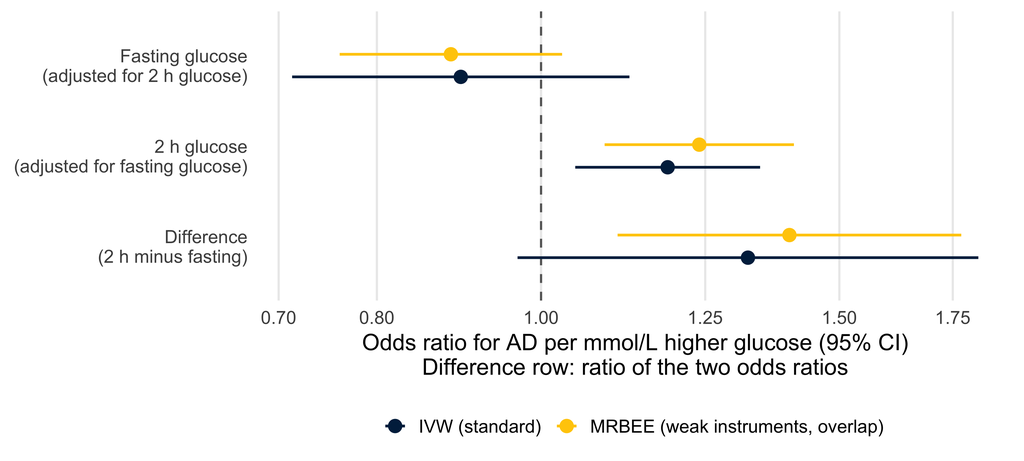

```r
mv |>
  filter(set == con_set) |>
  ggplot(aes(x = exp(b), xmin = exp(ci_lo), xmax = exp(ci_hi), y = term_label, colour = method_label)) +
  geom_vline(xintercept = 1, linetype = "dashed", colour = "grey40") +
  geom_pointrange(position = position_dodge(width = 0.5), linewidth = 0.9, size = 0.7) +
  scale_x_log10(breaks = c(0.7, 0.8, 1, 1.25, 1.5, 1.75)) +
  scale_colour_manual(values = con_cols) +
  labs(x = "Odds ratio for AD per mmol/L higher glucose (95% CI)\nDifference row: ratio of the two odds ratios",
       y = NULL, colour = NULL) +
  theme_talk
```

```r
mv |>
  filter(set %in% c("xue", "primary")) |>
  arrange(desc(set), method_label, desc(term_label)) |>
  transmute(`Instruments` = c(xue = "Xue 2018 (plotted)", primary = "Suzuki 2024 (pre-specified primary)")[set],
            Method = estimator, Term = gsub("\n", " ", term_label),
            `OR (95% CI)` = sprintf("%.2f (%.2f, %.2f)", exp(b), exp(ci_lo), exp(ci_hi)),
            p = signif(p, 2), SNPs = n_snp) |>
  kable()
```

| Instruments | Method | Term | OR (95% CI) | p | SNPs |
| --- | --- | --- | --- | --- | --- |
| Xue 2018 (plotted) | IVW-MRE | Fasting glucose (adjusted for 2 h glucose) | 0.90 (0.71, 1.13) | 0.3500 | 109 |
| Xue 2018 (plotted) | IVW-MRE | 2 h glucose (adjusted for fasting glucose) | 1.19 (1.05, 1.35) | 0.0073 | 109 |
| Xue 2018 (plotted) | IVW-MRE | Difference (2 h minus fasting) | 1.32 (0.97, 1.81) | 0.0780 | 109 |
| Xue 2018 (plotted) | MRBEE | Fasting glucose (adjusted for 2 h glucose) | 0.88 (0.76, 1.03) | 0.1100 | 109 |
| Xue 2018 (plotted) | MRBEE | 2 h glucose (adjusted for fasting glucose) | 1.24 (1.09, 1.41) | 0.0011 | 109 |
| Xue 2018 (plotted) | MRBEE | Difference (2 h minus fasting) | 1.40 (1.11, 1.77) | 0.0046 | 109 |
| Suzuki 2024 (pre-specified primary) | IVW-MRE | Fasting glucose (adjusted for 2 h glucose) | 1.03 (0.87, 1.23) | 0.7000 | 273 |
| Suzuki 2024 (pre-specified primary) | IVW-MRE | 2 h glucose (adjusted for fasting glucose) | 1.05 (0.97, 1.13) | 0.2400 | 273 |
| Suzuki 2024 (pre-specified primary) | IVW-MRE | Difference (2 h minus fasting) | 1.01 (0.81, 1.26) | 0.9000 | 273 |
| Suzuki 2024 (pre-specified primary) | MRBEE | Fasting glucose (adjusted for 2 h glucose) | 1.02 (0.84, 1.23) | 0.8600 | 273 |
| Suzuki 2024 (pre-specified primary) | MRBEE | 2 h glucose (adjusted for fasting glucose) | 1.09 (0.97, 1.21) | 0.1500 | 273 |
| Suzuki 2024 (pre-specified primary) | MRBEE | Difference (2 h minus fasting) | 1.07 (0.81, 1.40) | 0.6400 | 273 |

### Validation: are the two exposures separable, and what does “adjusted” look like?

Two checks on the plotted (Xue) instrument set.

**Left: the instruments vary their mix.** Each point is a variant’s effect on fasting glucose against its effect on 2 h glucose. If all points lay on one line through the origin, the model could not separate the two traits. They are correlated ($r$ shown) but spread widely, including variants that move 2 h glucose with little effect on fasting glucose; that spread is what the conditional F measures.

**Right: the added-variable plot for 2 h glucose.** Both the AD effects and the 2 h effects are regressed on the fasting effects (same weights as the model), and the residuals are plotted against each other. By the Frisch–Waugh–Lovell theorem the slope through these residuals is exactly the IVW estimate of $\theta_2$, so this panel is what “2 h glucose adjusted for fasting glucose” means: what is left of each variant’s 2 h effect once its fasting effect is accounted for, against what is left of its AD effect. Point size is the weight ($1/\sigma_{Yj}^2$). The line is the IVW slope; MRBEE corrects that slope for noise in the glucose effects, so it is somewhat steeper.

```r
val <- read_csv(file.path(con_dir, "instrument_outcome_data.csv"), show_col_types = FALSE) |>
  filter(set == con_set, outcome == ad_outcome, arm == con_arm) |>
  mutate(w = 1 / se_y^2)
val_strength <- read_csv(file.path(con_dir, "step0_strength.csv"), show_col_types = FALSE) |>
  filter(set == con_set)

# Frisch-Waugh-Lovell: residualise AD and 2 h effects on the fasting effects (weighted, no intercept);
# the slope of one set of residuals on the other is the multivariable IVW coefficient for 2 h glucose.
val <- val |>
  mutate(resid_y  = resid(lm(beta_y ~ 0 + beta_fg, weights = w)),
         resid_2h = resid(lm(beta_2h ~ 0 + beta_fg, weights = w)))
fwl_slope <- coef(lm(resid_y ~ 0 + resid_2h, data = val, weights = w))[[1]]
mv_slope  <- coef(lm(beta_y ~ 0 + beta_fg + beta_2h, data = val, weights = w))[["beta_2h"]]
stopifnot(abs(fwl_slope - mv_slope) < 1e-10)   # the added-variable slope IS the MVMR estimate
mrbee_2h <- mv |> filter(set == con_set, estimator == "MRBEE", term == "glu2h") |> pull(b)
```

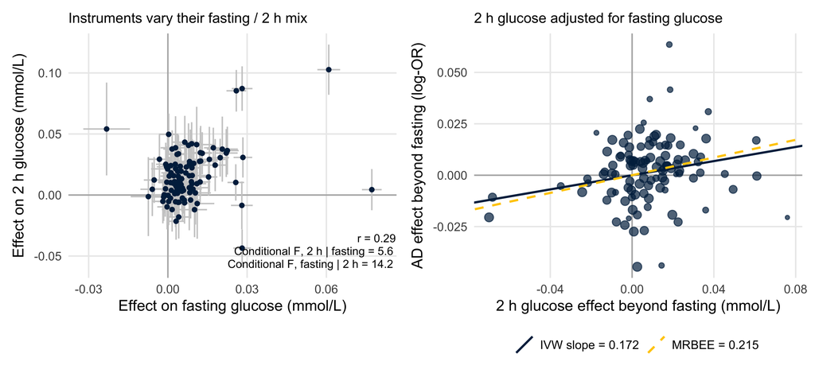

```r
p_mix <- ggplot(val, aes(beta_fg, beta_2h)) +
  geom_hline(yintercept = 0, colour = "grey70") + geom_vline(xintercept = 0, colour = "grey70") +
  geom_errorbar(aes(ymin = beta_2h - 1.96 * se_2h, ymax = beta_2h + 1.96 * se_2h), colour = "grey80", width = 0) +
  geom_errorbar(aes(xmin = beta_fg - 1.96 * se_fg, xmax = beta_fg + 1.96 * se_fg), colour = "grey80",
                width = 0, orientation = "y") +
  geom_point(colour = "#00274c", size = 1.8) +
  annotate("text", x = Inf, y = -Inf, hjust = 1.02, vjust = -0.3, size = 4.2, lineheight = 0.95,
           label = sprintf("r = %.2f\nConditional F, 2 h | fasting = %.1f\nConditional F, fasting | 2 h = %.1f",
                           cor(val$beta_fg, val$beta_2h), val_strength$cond_F_2h, val_strength$cond_F_fg)) +
  labs(x = "Effect on fasting glucose (mmol/L)", y = "Effect on 2 h glucose (mmol/L)",
       title = "Instruments vary their fasting / 2 h mix") +
  theme_talk + theme(panel.grid.major.y = element_line(), plot.title = element_text(size = 15))

p_avp <- ggplot(val, aes(resid_2h, resid_y)) +
  geom_hline(yintercept = 0, colour = "grey70") + geom_vline(xintercept = 0, colour = "grey70") +
  geom_point(aes(size = w), colour = "#00274c", alpha = 0.7, show.legend = FALSE) +
  geom_abline(aes(slope = fwl_slope, intercept = 0, colour = "IVW"), linewidth = 1.1) +
  geom_abline(aes(slope = mrbee_2h, intercept = 0, colour = "MRBEE"), linewidth = 1.1, linetype = "dashed") +
  scale_size_area(max_size = 4) +
  scale_colour_manual(values = c(IVW = "#00274c", MRBEE = "#ffcb05"),
                      labels = c(IVW = sprintf("IVW slope = %.3f", fwl_slope),
                                 MRBEE = sprintf("MRBEE = %.3f", mrbee_2h))) +
  labs(x = "2 h glucose effect beyond fasting (mmol/L)",
       y = "AD effect beyond fasting (log-OR)", colour = NULL,
       title = "2 h glucose adjusted for fasting glucose") +
  theme_talk + theme(panel.grid.major.y = element_line(), plot.title = element_text(size = 15))

patchwork::wrap_plots(p_mix, p_avp, nrow = 1)
```

## 7. T2D liability → AD by mechanistic cluster

```r
beta_levels <- c("All beta cell", "Beta cell -PI", "Beta cell +PI")
cl <- con_cl |>
  filter(set == "primary", outcome == ad_outcome, arm == con_arm,
         model == "T2D effect x cluster" | (model == "T2D effect x beta-cell" & grepl("^Beta", group))) |>
  mutate(group = if_else(model == "T2D effect x beta-cell", "All beta cell", group),
         ci_lo = b - 1.96 * se, ci_hi = b + 1.96 * se,
         kind = if_else(group %in% beta_levels, "Beta-cell clusters", "Other clusters")) |>
  arrange(kind != "Beta-cell clusters", match(group, beta_levels), desc(b)) |>
  mutate(label = sprintf("%s (%d)", group, n_snp), label = factor(label, levels = rev(label)))
cl_het <- con_cl |>
  filter(set == "primary", outcome == ad_outcome, arm == con_arm, model == "T2D effect x cluster") |>
  distinct(het_Q, het_df, het_p)
```

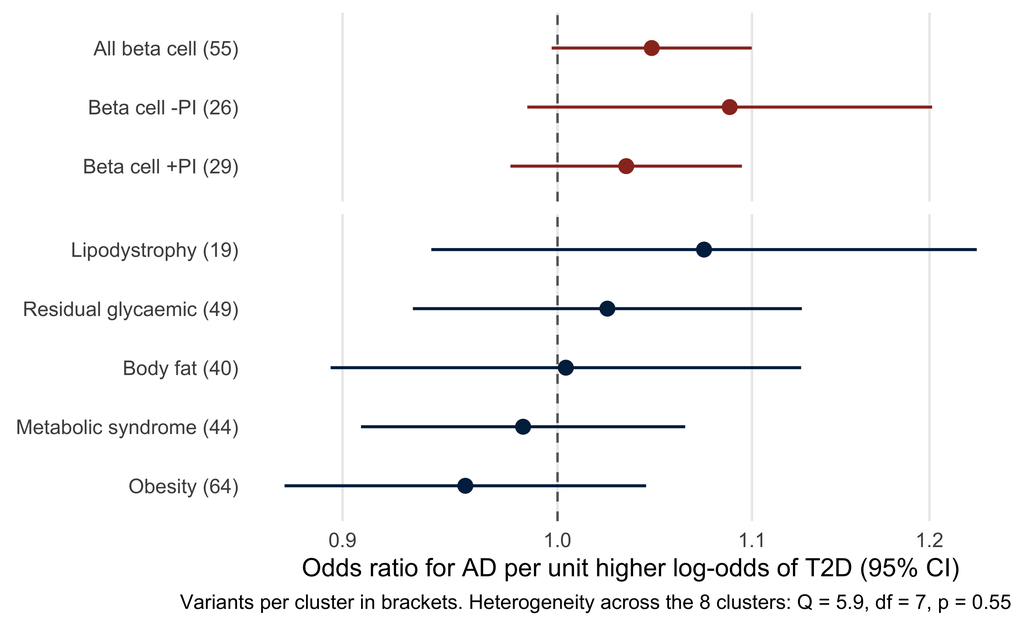

```r
cl |>
  filter(group != "other (small)") |>
  ggplot(aes(x = exp(b), xmin = exp(ci_lo), xmax = exp(ci_hi), y = label, colour = kind)) +
  geom_vline(xintercept = 1, linetype = "dashed", colour = "grey40") +
  geom_pointrange(linewidth = 0.9, size = 0.7) +
  facet_grid(kind ~ ., scales = "free_y", space = "free_y") +
  scale_x_log10() +
  scale_colour_manual(values = c("Beta-cell clusters" = "#9a3324", "Other clusters" = "#00274c"), guide = "none") +
  labs(x = "Odds ratio for AD per unit higher log-odds of T2D (95% CI)", y = NULL,
       caption = sprintf("Variants per cluster in brackets. Heterogeneity across the 8 clusters: Q = %.1f, df = %d, p = %.2f",
                         cl_het$het_Q, cl_het$het_df, cl_het$het_p)) +
  theme_talk + theme(strip.text.y = element_blank())
```

```r
cl |>
  transmute(Cluster = group, SNPs = n_snp,
            `OR (95% CI)` = sprintf("%.2f (%.2f, %.2f)", exp(b), exp(ci_lo), exp(ci_hi)), p = signif(p, 2)) |>
  kable()
```

| Cluster | SNPs | OR (95% CI) | p |
| --- | --- | --- | --- |
| All beta cell | 55 | 1.05 (1.00, 1.10) | 0.065 |
| Beta cell -PI | 26 | 1.09 (0.99, 1.20) | 0.095 |
| Beta cell +PI | 29 | 1.03 (0.98, 1.09) | 0.240 |
| Lipodystrophy | 19 | 1.07 (0.94, 1.23) | 0.290 |
| Residual glycaemic | 49 | 1.02 (0.93, 1.13) | 0.620 |
| Body fat | 40 | 1.00 (0.89, 1.13) | 0.940 |
| Metabolic syndrome | 44 | 0.98 (0.91, 1.06) | 0.680 |
| Obesity | 64 | 0.96 (0.87, 1.04) | 0.320 |
| other (small) | 2 | 0.88 (0.58, 1.34) | 0.550 |

### Cluster effects on glucose beside the effect on AD

The same variants, showing how T2D liability carried by each cluster moves fasting and 2 h glucose (right) next to its effect on AD (left). The glucose slopes are computed here from the per-variant table (`instrument_outcome_data.csv`) with the estimator used for AD: inverse-variance weighted regression through the origin on the variant’s T2D effect, random-effects standard error.

```r
con_snps <- read_csv(file.path(con_dir, "instrument_outcome_data.csv"), show_col_types = FALSE) |>
  filter(set == "primary", outcome == ad_outcome, arm == con_arm)

# IVW slope of a trait on the T2D effect, with the residual scale floored at 1 (as pipeline wls_mre()).
ivw_slope <- function(y, se, x) {
  f <- summary(lm(y ~ 0 + x, weights = 1 / se^2))
  tibble(b = f$coefficients[1, 1], se = f$coefficients[1, 2] / f$sigma * max(1, f$sigma))
}
cl_glu <- bind_rows(con_snps, con_snps |> filter(grepl("^Beta cell", cluster)) |> mutate(cluster = "All beta cell")) |>
  group_by(group = cluster) |>
  reframe(bind_rows(`Fasting glucose` = ivw_slope(beta_fg, se_fg, beta_t2d),
                    `2 h glucose` = ivw_slope(beta_2h, se_2h, beta_t2d), .id = "series")) |>
  mutate(ci_lo = b - 1.96 * se, ci_hi = b + 1.96 * se, panel = "Glucose")

cl_both <- cl |>
  transmute(group, series = "AD", b = exp(b), ci_lo = exp(ci_lo), ci_hi = exp(ci_hi), panel = "AD risk") |>
  bind_rows(cl_glu |> select(group, series, b, ci_lo, ci_hi, panel)) |>
  inner_join(cl |> select(group, label, kind), by = "group") |>
  filter(group != "other (small)") |>
  mutate(panel = factor(panel, levels = c("AD risk", "Glucose")))
```

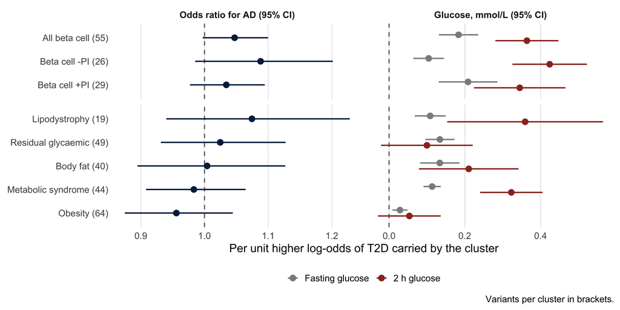

```r
ggplot(cl_both, aes(x = b, xmin = ci_lo, xmax = ci_hi, y = label, colour = series)) +
  geom_vline(data = data.frame(panel = factor(c("AD risk", "Glucose"), levels = c("AD risk", "Glucose")), x = c(1, 0)),
             aes(xintercept = x), linetype = "dashed", colour = "grey40") +
  geom_pointrange(position = position_dodge(width = 0.5), linewidth = 0.9, size = 0.6) +
  facet_grid(kind ~ panel, scales = "free", space = "free_y",
             labeller = labeller(panel = c(`AD risk` = "Odds ratio for AD (95% CI)",
                                           Glucose = "Glucose, mmol/L (95% CI)"))) +
  scale_colour_manual(values = c(AD = "#00274c", `Fasting glucose` = "grey55", `2 h glucose` = "#9a3324"),
                      breaks = c("Fasting glucose", "2 h glucose")) +
  labs(x = "Per unit higher log-odds of T2D carried by the cluster", y = NULL, colour = NULL,
       caption = "Variants per cluster in brackets.") +
  theme_talk + theme(strip.text.y = element_blank())
```

```r
cl_glu |>
  mutate(est = sprintf("%.2f (%.2f, %.2f)", b, ci_lo, ci_hi)) |>
  select(Cluster = group, series, est) |>
  pivot_wider(names_from = series, values_from = est) |>
  inner_join(cl |> transmute(Cluster = group, SNPs = n_snp,
                             `AD OR (95% CI)` = sprintf("%.2f (%.2f, %.2f)", exp(b), exp(ci_lo), exp(ci_hi))),
             by = "Cluster") |>
  arrange(match(Cluster, cl$group)) |>
  select(Cluster, SNPs, `AD OR (95% CI)`, `Fasting glucose`, `2 h glucose`) |>
  kable(caption = "Glucose columns: mmol/L per unit higher log-odds of T2D (95% CI).")
```

Glucose columns: mmol/L per unit higher log-odds of T2D (95% CI).

| Cluster | SNPs | AD OR (95% CI) | Fasting glucose | 2 h glucose |
| --- | --- | --- | --- | --- |
| All beta cell | 55 | 1.05 (1.00, 1.10) | 0.18 (0.13, 0.24) | 0.36 (0.28, 0.45) |
| Beta cell -PI | 26 | 1.09 (0.99, 1.20) | 0.10 (0.06, 0.15) | 0.42 (0.33, 0.52) |
| Beta cell +PI | 29 | 1.03 (0.98, 1.09) | 0.21 (0.13, 0.29) | 0.35 (0.22, 0.47) |
| Lipodystrophy | 19 | 1.07 (0.94, 1.23) | 0.11 (0.07, 0.15) | 0.36 (0.15, 0.57) |
| Residual glycaemic | 49 | 1.02 (0.93, 1.13) | 0.13 (0.10, 0.17) | 0.10 (-0.02, 0.22) |
| Body fat | 40 | 1.00 (0.89, 1.13) | 0.13 (0.08, 0.19) | 0.21 (0.08, 0.34) |
| Metabolic syndrome | 44 | 0.98 (0.91, 1.06) | 0.11 (0.09, 0.14) | 0.32 (0.24, 0.41) |
| Obesity | 64 | 0.96 (0.87, 1.04) | 0.03 (0.01, 0.05) | 0.05 (-0.03, 0.14) |

## 8. Drug targets

Variants in or near the gene for each glucose-lowering drug target (T2D-associated at p < 1×10⁻⁴, gene ± 100 kb; targets of drugs at phase 2 or later for T2D, Open Targets). Left: effect on AD of T2D liability acting through that target. Right: how the same variants move fasting and 2 h glucose, so each target’s fasting vs post-load profile sits beside its AD estimate. KATP channels and amylin receptors act on 2 h glucose only and show the clearest AD signals; glucokinase moves 2 h glucose most and shows none. Classes with fewer than 3 variants are in the table only.

```r
class_labels <- c(katp_secretagogue = "KATP channel (sulfonylureas)", amylin = "Amylin receptor",
                  pparg_sensitizer = "PPAR (glitazones)", glucokinase = "Glucokinase",
                  insulin_receptor = "Insulin receptor", incretin = "Incretin (GLP1R, GIPR, DPP4)",
                  fgf21_klb = "FGF21 / KLB", sglt = "SGLT", glucagon_receptor = "Glucagon receptor")
dt <- con_dt |>
  filter(set == "primary", level == "class") |>
  mutate(ci_lo = b - 1.96 * se, ci_hi = b + 1.96 * se,
         class = coalesce(class_labels[target], target))
dt_ad <- dt |> filter(outcome == ad_outcome, arm == con_arm, trait == "AD (log-OR)")
dt_order <- dt_ad |> arrange(b) |> mutate(label = sprintf("%s (%d)", class, n_snp))
dt_plot <- dt |>
  filter(outcome == ad_outcome, arm == con_arm, n_snp >= 3) |>
  inner_join(dt_order |> select(target, label), by = "target") |>
  mutate(label = factor(label, levels = dt_order$label),
         panel = factor(if_else(trait == "AD (log-OR)", "AD risk", "Glucose"), levels = c("AD risk", "Glucose")),
         series = case_when(trait == "AD (log-OR)" ~ "AD", grepl("^fasting", trait) ~ "Fasting glucose",
                            TRUE ~ "2 h glucose"),
         # AD as an odds ratio; glucose stays in mmol/L per unit log-odds of T2D
         across(c(b, ci_lo, ci_hi), \(v) if_else(panel == "AD risk", exp(v), v)))
```

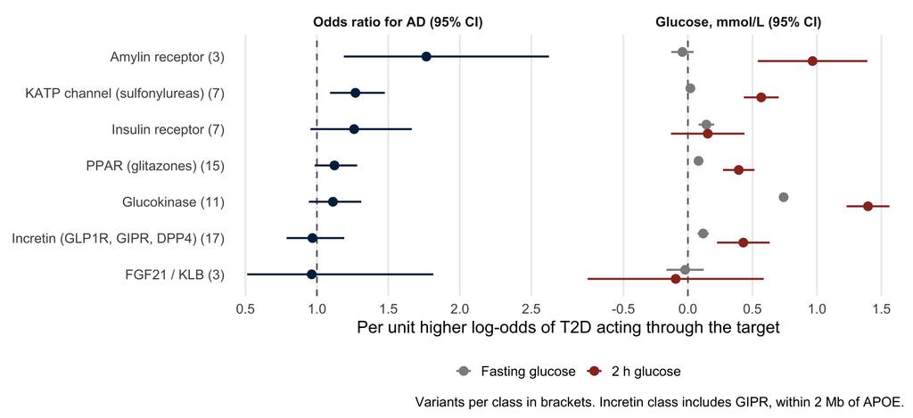

```r
ggplot(dt_plot, aes(x = b, xmin = ci_lo, xmax = ci_hi, y = label, colour = series)) +
  geom_vline(data = data.frame(panel = factor(c("AD risk", "Glucose"), levels = c("AD risk", "Glucose")), x = c(1, 0)),
             aes(xintercept = x), linetype = "dashed", colour = "grey40") +
  geom_pointrange(position = position_dodge(width = 0.5), linewidth = 0.9, size = 0.6) +
  facet_wrap(~ panel, scales = "free_x",
             labeller = as_labeller(c(`AD risk` = "Odds ratio for AD (95% CI)",
                                      Glucose = "Glucose, mmol/L (95% CI)"))) +
  scale_colour_manual(values = c(AD = "#00274c", `Fasting glucose` = "grey55", `2 h glucose` = "#9a3324"),
                      breaks = c("Fasting glucose", "2 h glucose")) +
  labs(x = "Per unit higher log-odds of T2D acting through the target", y = NULL, colour = NULL,
       caption = "Variants per class in brackets. Incretin class includes GIPR, within 2 Mb of APOE.") +
  theme_talk
```

```r
dt |>
  filter(trait == "AD (log-OR)") |>
  mutate(Outcome = paste(c(ad_bellenguez = "Bellenguez", ad_kunkle = "Kunkle")[outcome], arm_labels[arm], sep = ", ")) |>
  transmute(Class = class, Outcome, SNPs = n_snp,
            `OR (95% CI)` = sprintf("%.2f (%.2f, %.2f)", exp(b), exp(ci_lo), exp(ci_hi)), p = signif(p, 2)) |>
  arrange(Class, Outcome) |>
  kable()
```

| Class | Outcome | SNPs | OR (95% CI) | p |
| --- | --- | --- | --- | --- |
| Amylin receptor | Bellenguez, SlopeHunter-corrected | 3 | 1.77 (1.19, 2.62) | 0.0049 |
| Amylin receptor | Bellenguez, Uncorrected | 3 | 1.51 (1.03, 2.22) | 0.0340 |
| Amylin receptor | Kunkle, Uncorrected | 3 | 1.47 (0.74, 2.93) | 0.2700 |
| FGF21 / KLB | Bellenguez, SlopeHunter-corrected | 3 | 0.96 (0.51, 1.81) | 0.9100 |
| FGF21 / KLB | Bellenguez, Uncorrected | 4 | 0.93 (0.59, 1.47) | 0.7600 |
| FGF21 / KLB | Kunkle, Uncorrected | 4 | 1.32 (0.57, 3.04) | 0.5100 |
| Glucokinase | Bellenguez, SlopeHunter-corrected | 11 | 1.11 (0.94, 1.31) | 0.2100 |
| Glucokinase | Bellenguez, Uncorrected | 11 | 1.05 (0.89, 1.23) | 0.5600 |
| Glucokinase | Kunkle, Uncorrected | 9 | 0.91 (0.67, 1.22) | 0.5100 |
| Incretin (GLP1R, GIPR, DPP4) | Bellenguez, SlopeHunter-corrected | 17 | 0.97 (0.79, 1.19) | 0.7600 |
| Incretin (GLP1R, GIPR, DPP4) | Bellenguez, Uncorrected | 17 | 0.99 (0.81, 1.20) | 0.8800 |
| Incretin (GLP1R, GIPR, DPP4) | Kunkle, Uncorrected | 15 | 0.65 (0.45, 0.93) | 0.0190 |
| Insulin receptor | Bellenguez, SlopeHunter-corrected | 7 | 1.26 (0.95, 1.66) | 0.1000 |
| Insulin receptor | Bellenguez, Uncorrected | 7 | 1.19 (0.91, 1.56) | 0.2100 |
| Insulin receptor | Kunkle, Uncorrected | 6 | 2.11 (1.30, 3.42) | 0.0027 |
| KATP channel (sulfonylureas) | Bellenguez, SlopeHunter-corrected | 7 | 1.27 (1.09, 1.48) | 0.0019 |
| KATP channel (sulfonylureas) | Bellenguez, Uncorrected | 7 | 1.25 (1.08, 1.44) | 0.0030 |
| KATP channel (sulfonylureas) | Kunkle, Uncorrected | 5 | 1.01 (0.72, 1.40) | 0.9800 |
| PPAR (glitazones) | Bellenguez, SlopeHunter-corrected | 15 | 1.12 (0.98, 1.28) | 0.0860 |
| PPAR (glitazones) | Bellenguez, Uncorrected | 16 | 1.07 (0.95, 1.22) | 0.2600 |
| PPAR (glitazones) | Kunkle, Uncorrected | 14 | 1.20 (0.96, 1.51) | 0.1100 |
| SGLT | Bellenguez, SlopeHunter-corrected | 2 | 1.13 (0.54, 2.35) | 0.7500 |
| SGLT | Bellenguez, Uncorrected | 2 | 1.13 (0.55, 2.31) | 0.7400 |
| SGLT | Kunkle, Uncorrected | 2 | 1.43 (0.41, 5.02) | 0.5800 |